# Preliminary cumulative-mortality model results

Life-stage and pooled climate-niche change models

# 1 Overview

This report assembles the current preliminary cumulative-mortality results for seedling, sapling, adult, and pooled all-live forest-community climate niches. The three responses are raw first-to-last changes in temperature, precipitation, and climatic water deficit (CWD) community-weighted means.

Every model includes cumulative fire, insect, and disease mortality, cumulative site-level TerraClimate CWD over the complete survey period, and the length of that survey period. Model coefficients are unstandardized. The model tables report HC1 uncertainty clustered by stable FIA plot.

For each response, the raw-relationship figures show the observed response and one focal driver without covariate adjustment. The marginal-effect figures show the fitted relationship for that driver at one shared covariate reference: other agent mortalities equal zero, with site CWD and survey duration fixed at their pooled-history medians when they are not focal. These are preliminary associations, not final causal estimates.

# 2 Model samples

Rows and stable FIA plots represented in the preliminary models.

| model_id | group | group_label | response | available_rows | complete_rows | excluded_rows | stable_plots | positive_fire | positive_insect | positive_disease |
| --- | --- | --- | --- | --- | --- | --- | --- | --- | --- | --- |
| seedlings__temperature | seedlings | Seedlings | temperature | 64517 | 59395 | 5122 | 58711 | 2581 | 11876 | 19130 |
| saplings__temperature | saplings | Saplings | temperature | 56373 | 50463 | 5910 | 50031 | 1320 | 10222 | 16592 |
| trees__temperature | trees | Adults | temperature | 76320 | 73981 | 2339 | 72893 | 3245 | 14446 | 22026 |
| community__temperature | community | Pooled all live | temperature | 77831 | 77669 | 162 | 76422 | 3749 | 14776 | 22705 |
| seedlings__precipitation | seedlings | Seedlings | precipitation | 64517 | 59395 | 5122 | 58711 | 2581 | 11876 | 19130 |
| saplings__precipitation | saplings | Saplings | precipitation | 56373 | 50463 | 5910 | 50031 | 1320 | 10222 | 16592 |
| trees__precipitation | trees | Adults | precipitation | 76320 | 73981 | 2339 | 72893 | 3245 | 14446 | 22026 |
| community__precipitation | community | Pooled all live | precipitation | 77831 | 77669 | 162 | 76422 | 3749 | 14776 | 22705 |
| seedlings__CWD | seedlings | Seedlings | CWD | 64517 | 59395 | 5122 | 58711 | 2581 | 11876 | 19130 |
| saplings__CWD | saplings | Saplings | CWD | 56373 | 50463 | 5910 | 50031 | 1320 | 10222 | 16592 |
| trees__CWD | trees | Adults | CWD | 76320 | 73981 | 2339 | 72893 | 3245 | 14446 | 22026 |
| community__CWD | community | Pooled all live | CWD | 77831 | 77669 | 162 | 76422 | 3749 | 14776 | 22705 |

# 3 Temperature CWM change

## 3.1 Model results

Temperature CWM change

|  | Seedlings |  |  |  | Saplings |  |  |  | Adults |  |  |  | Pooled all live |  |  |  |
| --- | --- | --- | --- | --- | --- | --- | --- | --- | --- | --- | --- | --- | --- | --- | --- | --- |
| Predictor | Estimate | HC1 SE | 95% CI | p | Estimate | HC1 SE | 95% CI | p | Estimate | HC1 SE | 95% CI | p | Estimate | HC1 SE | 95% CI | p |
| Intercept | -0.0274541 | 0.0146595 | -0.0561867 – 0.0012785 | 0.061 | -0.0349704 | 0.0134661 | -0.0613641 – -0.0085766 | **0.009** | -0.0548260 | 0.0072919 | -0.0691180 – -0.0405339 | **<0.001** | -0.0482405 | 0.0096211 | -0.0670978 – -0.0293832 | **<0.001** |
| Cumulative fire mortality (%) | -0.0007185 | 0.0004244 | -0.0015504 – 0.0001133 | 0.090 | 0.0005806 | 0.0008763 | -0.0011369 – 0.0022981 | 0.508 | 0.0010179 | 0.0002887 | 0.0004522 – 0.0015837 | **<0.001** | 0.0000419 | 0.0003075 | -0.0005608 – 0.0006445 | 0.892 |
| Cumulative insect mortality (%) | -0.0004888 | 0.0005688 | -0.0016037 – 0.0006262 | 0.390 | 0.0018823 | 0.0008110 | 0.0002927 – 0.0034719 | **0.020** | 0.0016926 | 0.0004011 | 0.0009065 – 0.0024787 | **<0.001** | 0.0006127 | 0.0004497 | -0.0002688 – 0.0014941 | 0.173 |
| Cumulative disease mortality (%) | 0.0003274 | 0.0006821 | -0.0010095 – 0.0016643 | 0.631 | 0.0015128 | 0.0008342 | -0.0001221 – 0.0031478 | 0.070 | 0.0002597 | 0.0003840 | -0.0004930 – 0.0010124 | 0.499 | 0.0013091 | 0.0004664 | 0.0003950 – 0.0022232 | **0.005** |
| Cumulative site CWD (mm) | -0.0000055 | 0.0000011 | -0.0000076 – -0.0000034 | **<0.001** | -0.0000054 | 0.0000010 | -0.0000074 – -0.0000035 | **<0.001** | -0.0000015 | 0.0000006 | -0.0000027 – -0.0000003 | **0.013** | -0.0000020 | 0.0000007 | -0.0000033 – -0.0000006 | **0.004** |
| Full survey period (years) | 0.0083537 | 0.0010555 | 0.0062850 – 0.0104223 | **<0.001** | 0.0064010 | 0.0010818 | 0.0042807 – 0.0085213 | **<0.001** | 0.0077204 | 0.0006128 | 0.0065192 – 0.0089215 | **<0.001** | 0.0077678 | 0.0007150 | 0.0063665 – 0.0091691 | **<0.001** |
| Observations | 59395 |  |  |  | 50463 |  |  |  | 73981 |  |  |  | 77669 |  |  |  |
| R<sup>2</sup> / R<sup>2</sup> adjusted | 0.0016 / 0.0016 |  |  |  | 0.0013 / 0.0012 |  |  |  | 0.0034 / 0.0033 |  |  |  | 0.0022 / 0.0021 |  |  |  |

## 3.2 Raw relationships

### 3.2.1 Fire mortality

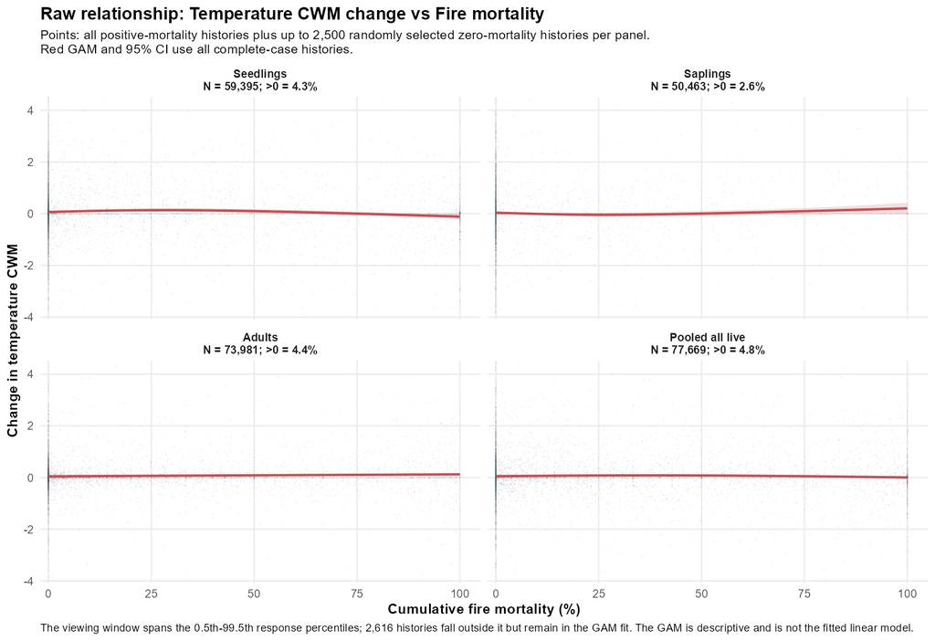

Fire mortality

Complete-case raw observations and descriptive GAM for Seedlings, Saplings, Adults, Pooled all live

### 3.2.2 Insect mortality

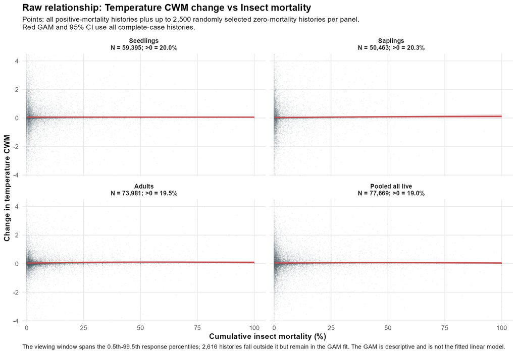

Insect mortality

Complete-case raw observations and descriptive GAM for Seedlings, Saplings, Adults, Pooled all live

### 3.2.3 Disease mortality

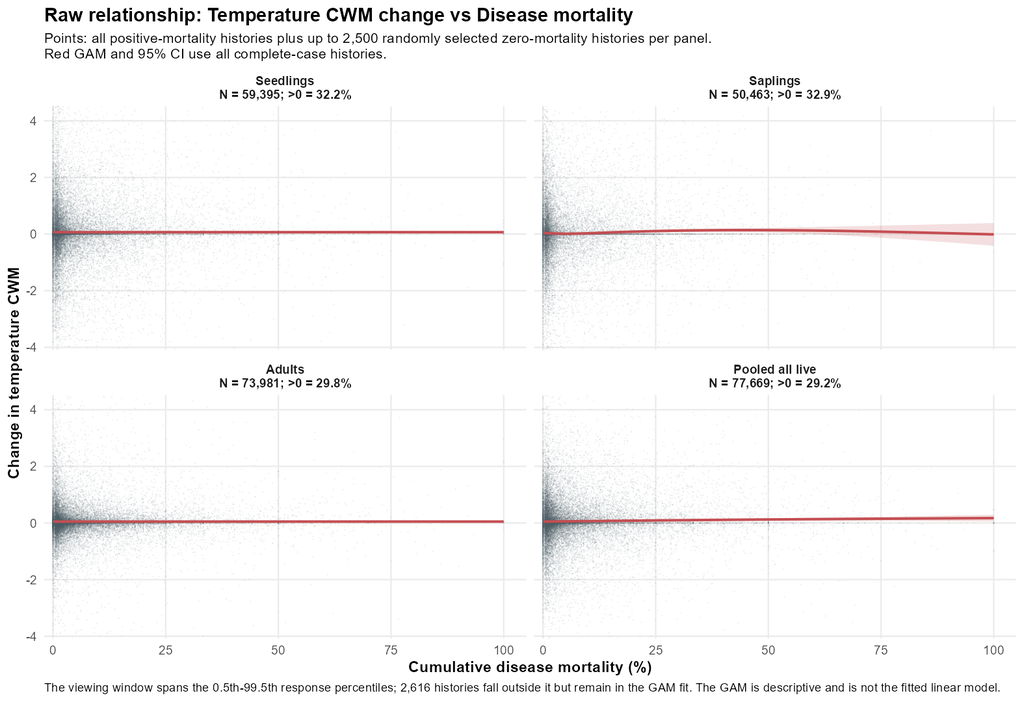

Disease mortality

Complete-case raw observations and descriptive GAM for Seedlings, Saplings, Adults, Pooled all live

### 3.2.4 Cumulative site CWD

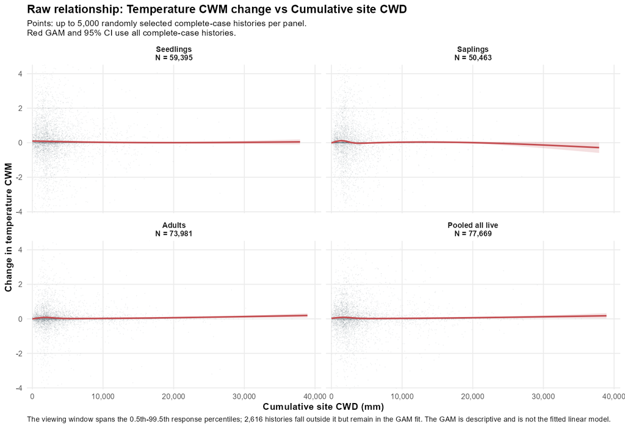

Cumulative site CWD

Complete-case raw observations and descriptive GAM for Seedlings, Saplings, Adults, Pooled all live

## 3.3 Adjusted marginal effects

### 3.3.1 Fire mortality

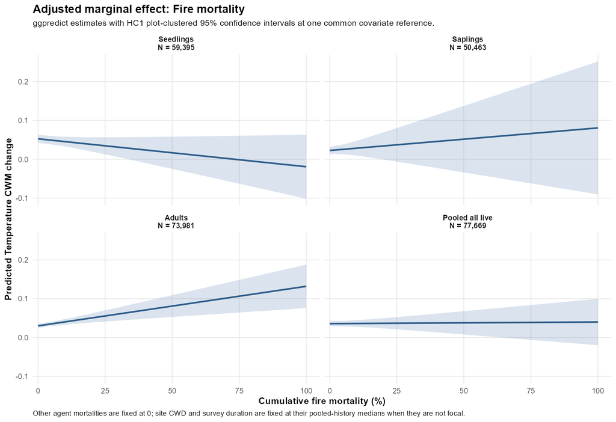

Fire mortality

HC1 plot-clustered ggpredict estimates for Seedlings, Saplings, Adults, Pooled all live

### 3.3.2 Insect mortality

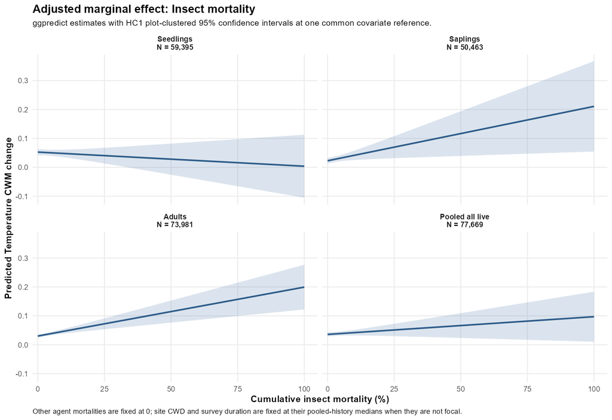

Insect mortality

HC1 plot-clustered ggpredict estimates for Seedlings, Saplings, Adults, Pooled all live

### 3.3.3 Disease mortality

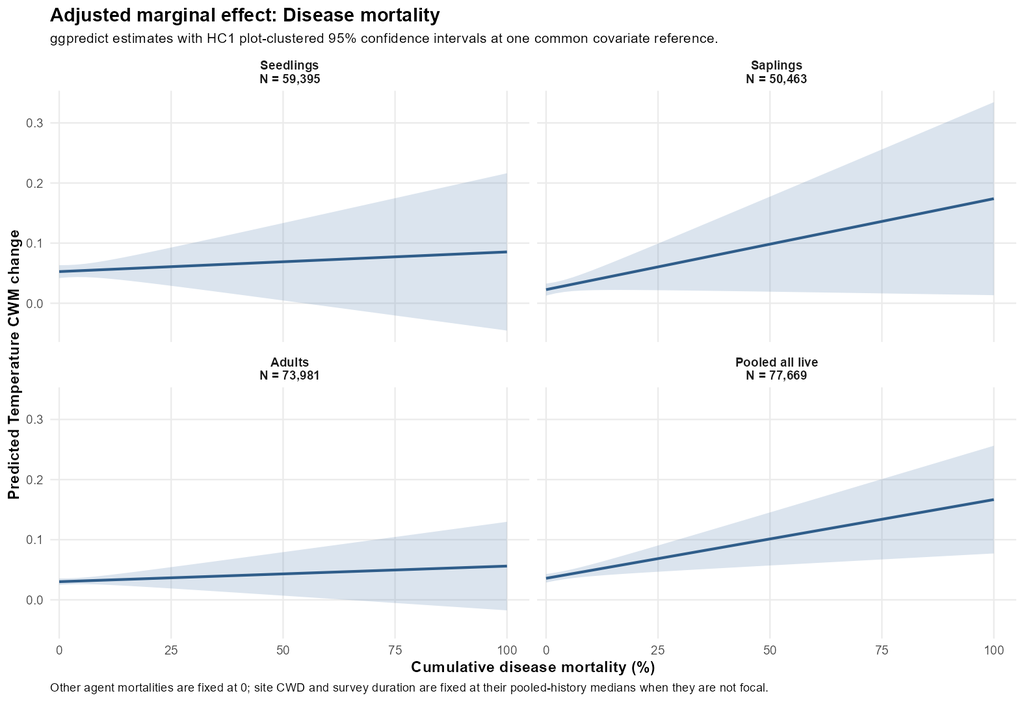

Disease mortality

HC1 plot-clustered ggpredict estimates for Seedlings, Saplings, Adults, Pooled all live

### 3.3.4 Cumulative site CWD

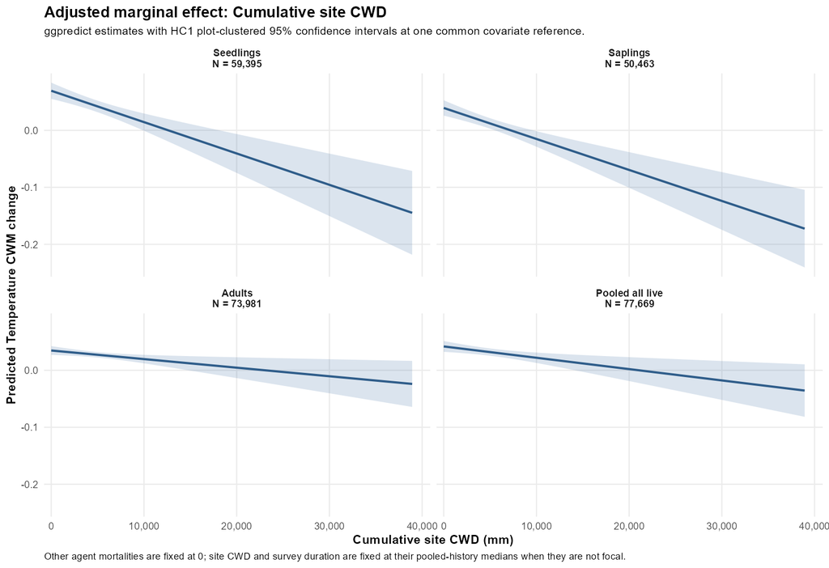

Cumulative site CWD

HC1 plot-clustered ggpredict estimates for Seedlings, Saplings, Adults, Pooled all live

# 4 Precipitation CWM change

## 4.1 Model results

Precipitation CWM change

|  | Seedlings |  |  |  | Saplings |  |  |  | Adults |  |  |  | Pooled all live |  |  |  |
| --- | --- | --- | --- | --- | --- | --- | --- | --- | --- | --- | --- | --- | --- | --- | --- | --- |
| Predictor | Estimate | HC1 SE | 95% CI | p | Estimate | HC1 SE | 95% CI | p | Estimate | HC1 SE | 95% CI | p | Estimate | HC1 SE | 95% CI | p |
| Intercept | 2.0720827 | 0.9811014 | 0.1491200 – 3.9950454 | **0.035** | 3.0349905 | 0.9000678 | 1.2708477 – 4.7991332 | **0.001** | 0.2972679 | 0.4745310 | -0.6328110 – 1.2273468 | 0.531 | 0.6309138 | 0.6756560 | -0.6933682 – 1.9551958 | 0.350 |
| Cumulative fire mortality (%) | 0.1217261 | 0.0487944 | 0.0260889 – 0.2173633 | **0.013** | 0.1073492 | 0.0850980 | -0.0594439 – 0.2741423 | 0.207 | -0.1638292 | 0.0287206 | -0.2201216 – -0.1075369 | **<0.001** | 0.0644583 | 0.0343081 | -0.0027855 – 0.1317021 | 0.060 |
| Cumulative insect mortality (%) | -0.0234185 | 0.0375394 | -0.0969959 – 0.0501588 | 0.533 | -0.1203104 | 0.0523817 | -0.2229792 – -0.0176416 | **0.022** | -0.0330060 | 0.0203451 | -0.0728824 – 0.0068704 | 0.105 | 0.0023782 | 0.0276561 | -0.0518276 – 0.0565840 | 0.931 |
| Cumulative disease mortality (%) | -0.0168171 | 0.0435488 | -0.1021728 – 0.0685387 | 0.699 | 0.0560537 | 0.0551884 | -0.0521161 – 0.1642235 | 0.310 | -0.1326057 | 0.0279557 | -0.1873986 – -0.0778127 | **<0.001** | 0.0073062 | 0.0327350 | -0.0568543 – 0.0714666 | 0.823 |
| Cumulative site CWD (mm) | -0.0003277 | 0.0000830 | -0.0004903 – -0.0001651 | **<0.001** | -0.0005065 | 0.0000676 | -0.0006390 – -0.0003739 | **<0.001** | -0.0002545 | 0.0000346 | -0.0003223 – -0.0001867 | **<0.001** | -0.0002753 | 0.0000456 | -0.0003647 – -0.0001860 | **<0.001** |
| Full survey period (years) | 0.3240166 | 0.0610751 | 0.2043091 – 0.4437240 | **<0.001** | 0.2347352 | 0.0604912 | 0.1161717 – 0.3532986 | **<0.001** | 0.2440089 | 0.0334990 | 0.1783511 – 0.3096668 | **<0.001** | 0.3370188 | 0.0433611 | 0.2520313 – 0.4220064 | **<0.001** |
| Observations | 59395 |  |  |  | 50463 |  |  |  | 73981 |  |  |  | 77669 |  |  |  |
| R<sup>2</sup> / R<sup>2</sup> adjusted | 0.0009 / 0.0009 |  |  |  | 0.0012 / 0.0011 |  |  |  | 0.0034 / 0.0033 |  |  |  | 0.0012 / 0.0012 |  |  |  |

## 4.2 Raw relationships

### 4.2.1 Fire mortality

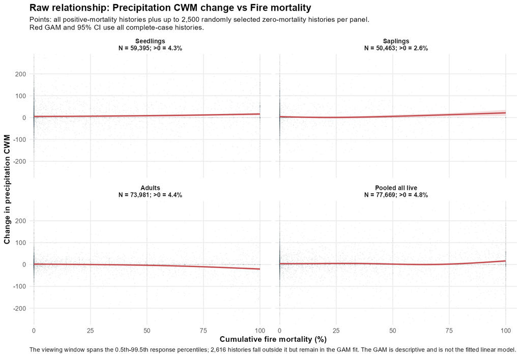

Fire mortality

Complete-case raw observations and descriptive GAM for Seedlings, Saplings, Adults, Pooled all live

### 4.2.2 Insect mortality

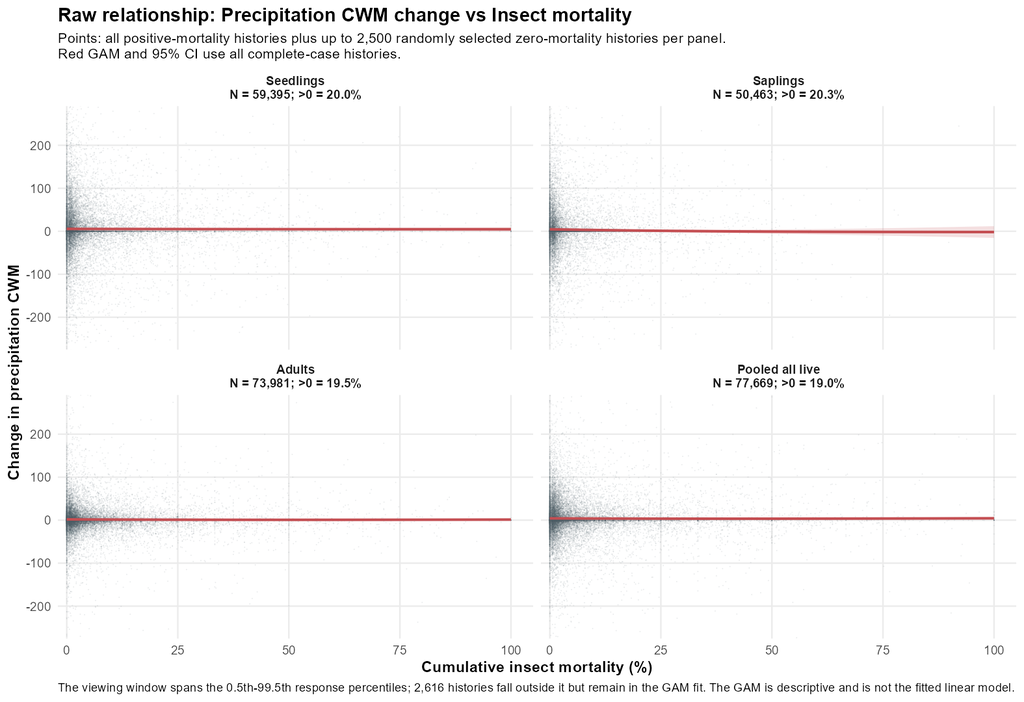

Insect mortality

Complete-case raw observations and descriptive GAM for Seedlings, Saplings, Adults, Pooled all live

### 4.2.3 Disease mortality

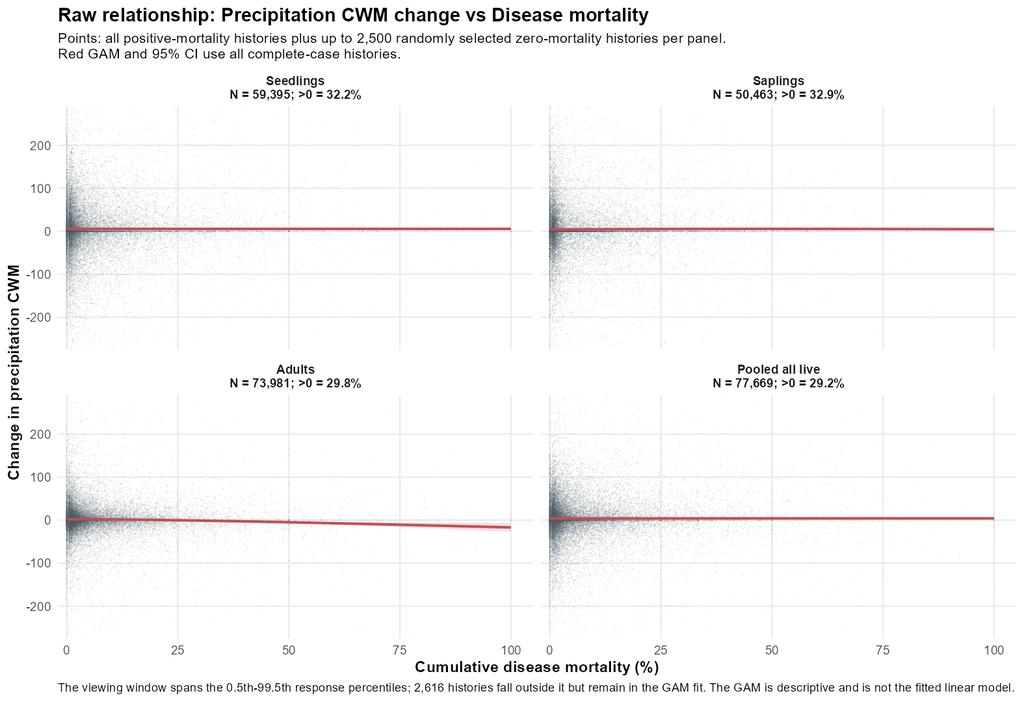

Disease mortality

Complete-case raw observations and descriptive GAM for Seedlings, Saplings, Adults, Pooled all live

### 4.2.4 Cumulative site CWD

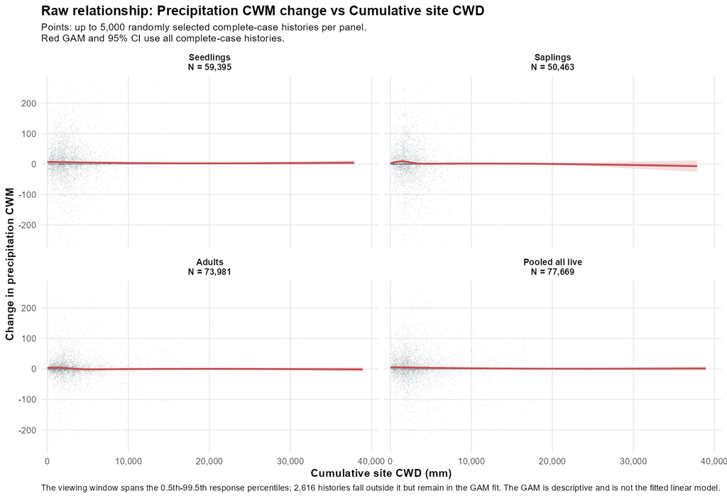

Cumulative site CWD

Complete-case raw observations and descriptive GAM for Seedlings, Saplings, Adults, Pooled all live

## 4.3 Adjusted marginal effects

### 4.3.1 Fire mortality

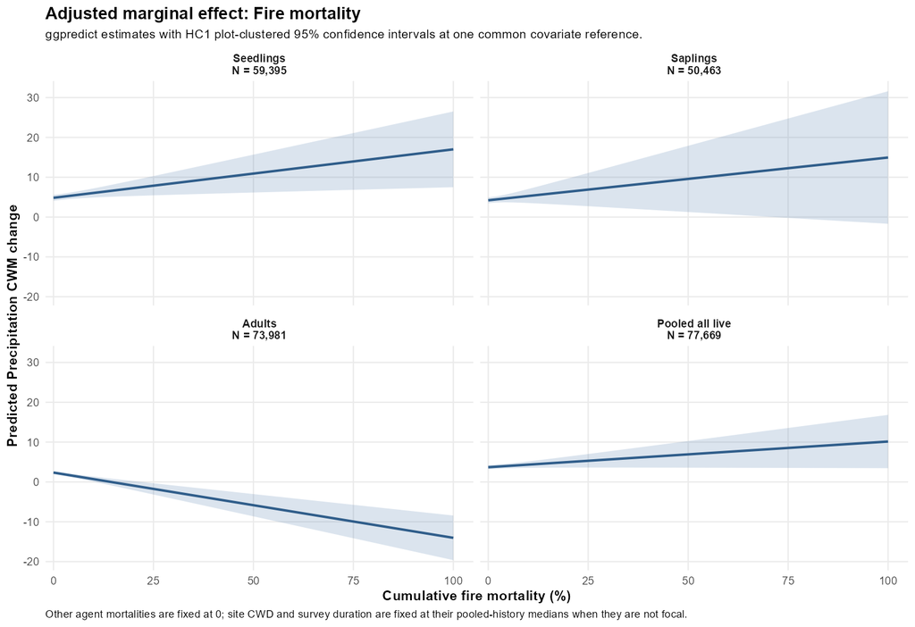

Fire mortality

HC1 plot-clustered ggpredict estimates for Seedlings, Saplings, Adults, Pooled all live

### 4.3.2 Insect mortality

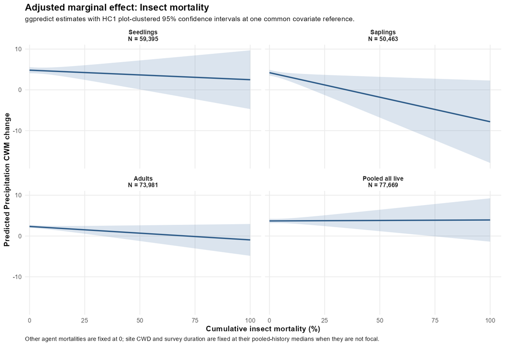

Insect mortality

HC1 plot-clustered ggpredict estimates for Seedlings, Saplings, Adults, Pooled all live

### 4.3.3 Disease mortality

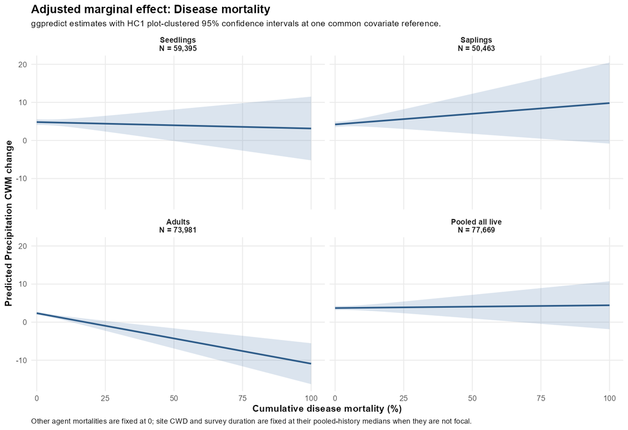

Disease mortality

HC1 plot-clustered ggpredict estimates for Seedlings, Saplings, Adults, Pooled all live

### 4.3.4 Cumulative site CWD

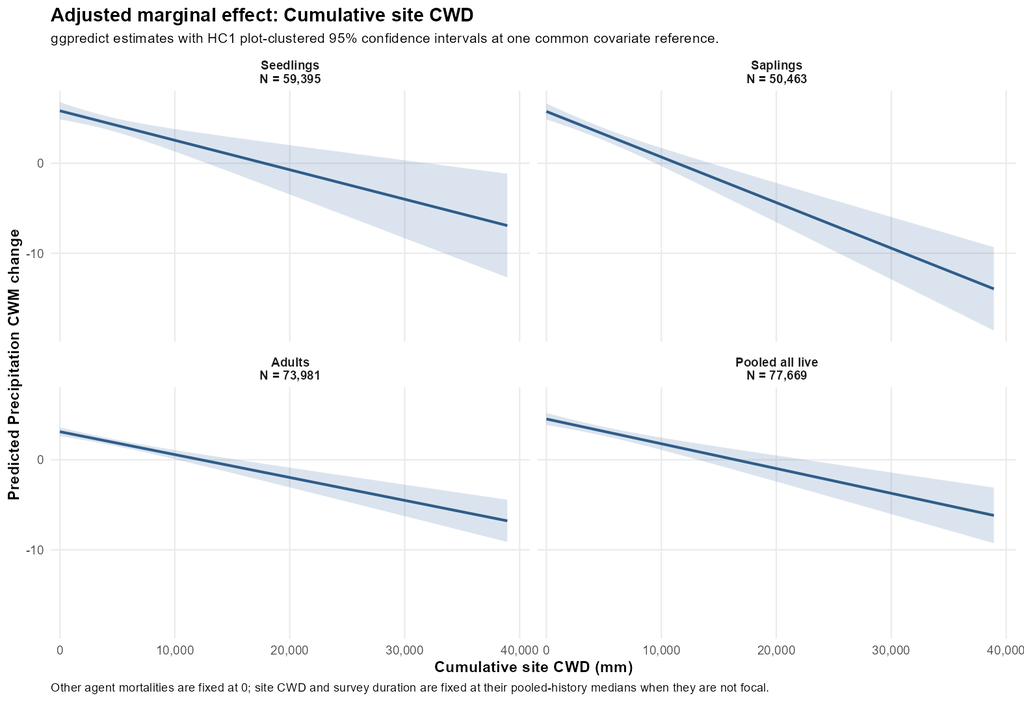

Cumulative site CWD

HC1 plot-clustered ggpredict estimates for Seedlings, Saplings, Adults, Pooled all live

# 5 CWD CWM change

## 5.1 Model results

CWD CWM change

|  | Seedlings |  |  |  | Saplings |  |  |  | Adults |  |  |  | Pooled all live |  |  |  |
| --- | --- | --- | --- | --- | --- | --- | --- | --- | --- | --- | --- | --- | --- | --- | --- | --- |
| Predictor | Estimate | HC1 SE | 95% CI | p | Estimate | HC1 SE | 95% CI | p | Estimate | HC1 SE | 95% CI | p | Estimate | HC1 SE | 95% CI | p |
| Intercept | -2.1024315 | 0.8247831 | -3.7190096 – -0.4858533 | **0.011** | -1.8791866 | 0.7235810 | -3.2974133 – -0.4609600 | **0.009** | -1.6029326 | 0.4178454 | -2.4219080 – -0.7839573 | **<0.001** | -1.9933527 | 0.5958462 | -3.1612079 – -0.8254974 | **0.001** |
| Cumulative fire mortality (%) | -0.2108104 | 0.0462694 | -0.3014986 – -0.1201222 | **<0.001** | 0.0027443 | 0.0827786 | -0.1595027 – 0.1649913 | 0.974 | 0.1326059 | 0.0268607 | 0.0799589 – 0.1852529 | **<0.001** | -0.1126615 | 0.0333718 | -0.1780700 – -0.0472530 | **0.001** |
| Cumulative insect mortality (%) | -0.0198092 | 0.0411631 | -0.1004890 – 0.0608706 | 0.630 | 0.1947139 | 0.0553603 | 0.0862070 – 0.3032208 | **<0.001** | 0.1005624 | 0.0224053 | 0.0566481 – 0.1444766 | **<0.001** | 0.0149680 | 0.0336747 | -0.0510342 – 0.0809703 | 0.657 |
| Cumulative disease mortality (%) | 0.0340918 | 0.0431300 | -0.0504432 – 0.1186268 | 0.429 | 0.0062378 | 0.0505784 | -0.0928965 – 0.1053721 | 0.902 | 0.1897840 | 0.0314899 | 0.1280638 – 0.2515041 | **<0.001** | 0.0804777 | 0.0347053 | 0.0124555 – 0.1484999 | **0.020** |
| Cumulative site CWD (mm) | 0.0001778 | 0.0001002 | -0.0000185 – 0.0003742 | 0.076 | 0.0002179 | 0.0000808 | 0.0000595 – 0.0003763 | **0.007** | 0.0001927 | 0.0000435 | 0.0001075 – 0.0002778 | **<0.001** | 0.0002393 | 0.0000564 | 0.0001288 – 0.0003498 | **<0.001** |
| Full survey period (years) | -0.0896441 | 0.0513056 | -0.1902033 – 0.0109152 | 0.081 | -0.1239999 | 0.0471127 | -0.2163414 – -0.0316585 | **0.008** | 0.0120898 | 0.0268781 | -0.0405911 – 0.0647707 | 0.653 | -0.0938276 | 0.0377155 | -0.1677498 – -0.0199054 | **0.013** |
| Observations | 59395 |  |  |  | 50463 |  |  |  | 73981 |  |  |  | 77669 |  |  |  |
| R<sup>2</sup> / R<sup>2</sup> adjusted | 0.0014 / 0.0013 |  |  |  | 0.0008 / 0.0007 |  |  |  | 0.0035 / 0.0034 |  |  |  | 0.0011 / 0.0010 |  |  |  |

## 5.2 Raw relationships

### 5.2.1 Fire mortality

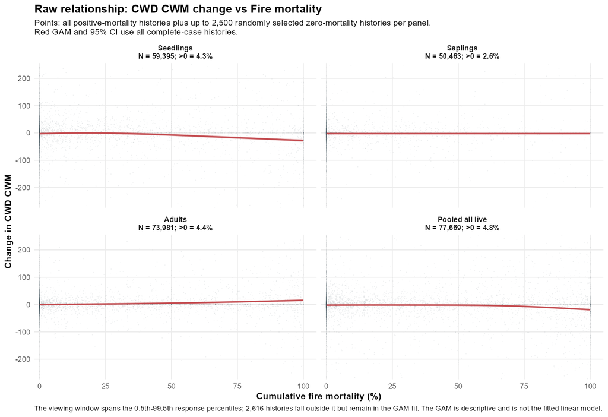

Fire mortality

Complete-case raw observations and descriptive GAM for Seedlings, Saplings, Adults, Pooled all live

### 5.2.2 Insect mortality

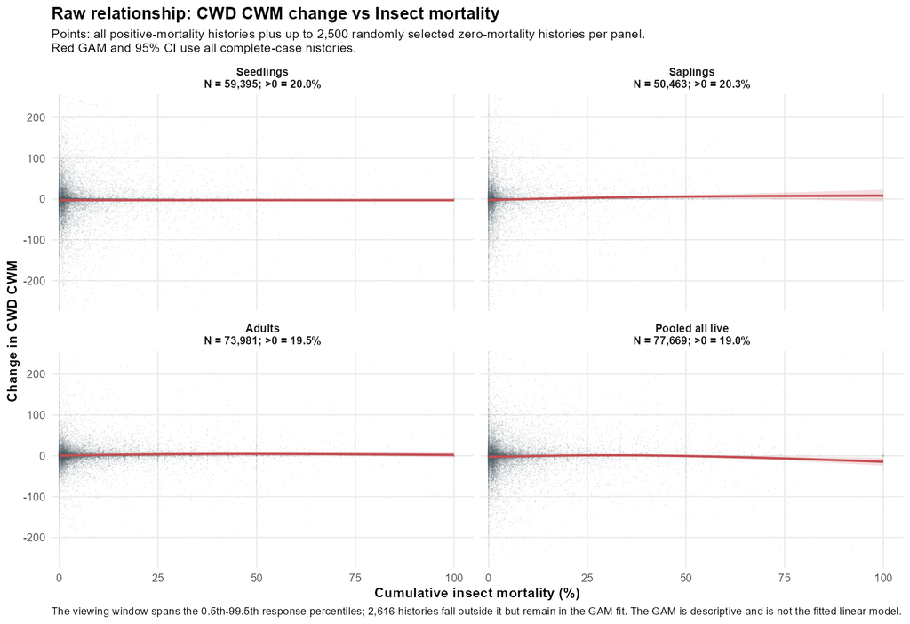

Insect mortality

Complete-case raw observations and descriptive GAM for Seedlings, Saplings, Adults, Pooled all live

### 5.2.3 Disease mortality

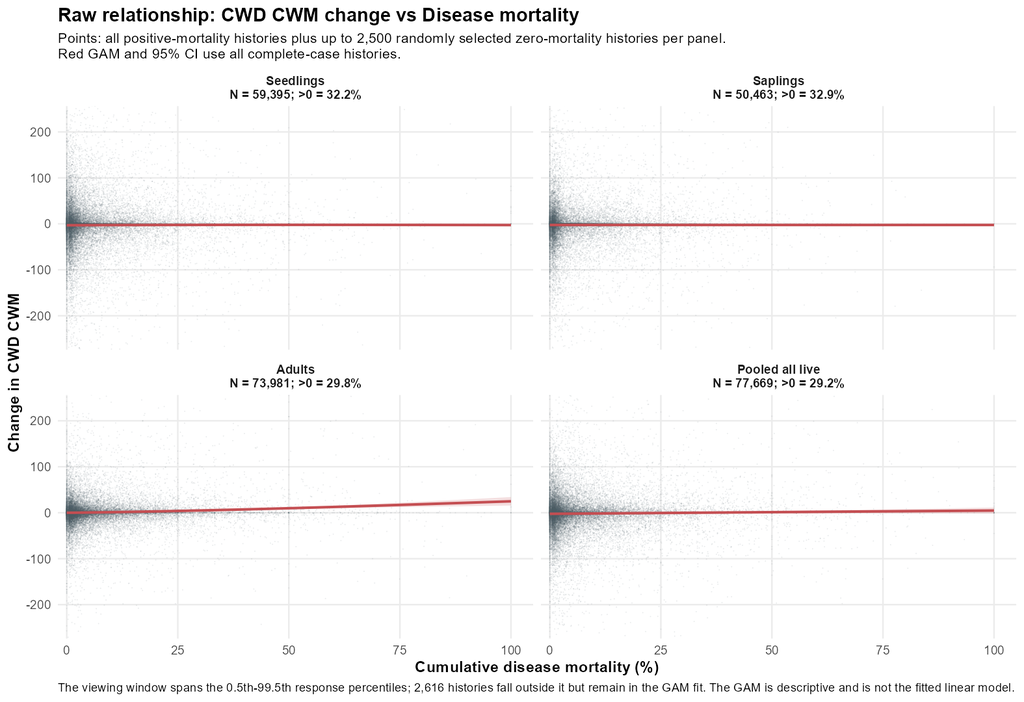

Disease mortality

Complete-case raw observations and descriptive GAM for Seedlings, Saplings, Adults, Pooled all live

### 5.2.4 Cumulative site CWD

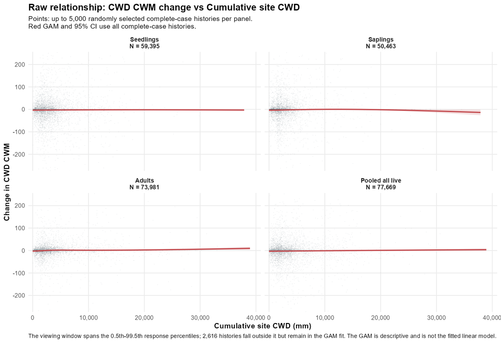

Cumulative site CWD

Complete-case raw observations and descriptive GAM for Seedlings, Saplings, Adults, Pooled all live

## 5.3 Adjusted marginal effects

### 5.3.1 Fire mortality

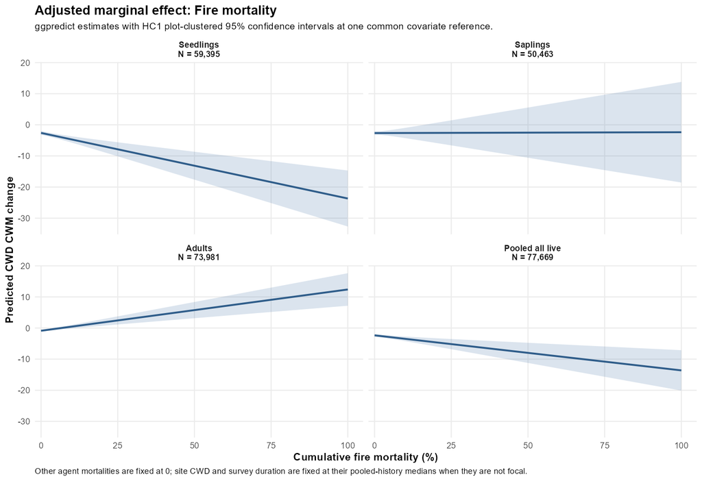

Fire mortality

HC1 plot-clustered ggpredict estimates for Seedlings, Saplings, Adults, Pooled all live

### 5.3.2 Insect mortality

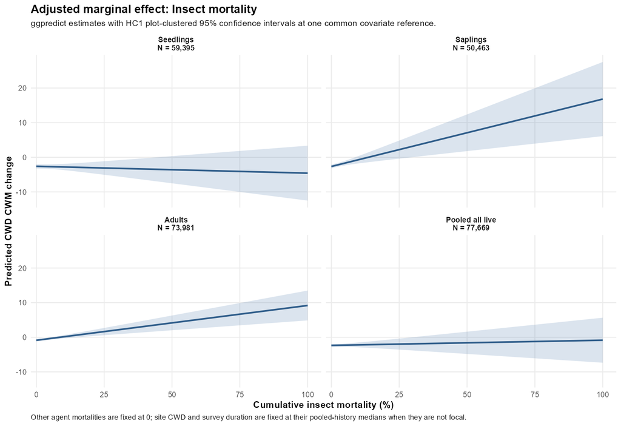

Insect mortality

HC1 plot-clustered ggpredict estimates for Seedlings, Saplings, Adults, Pooled all live

### 5.3.3 Disease mortality

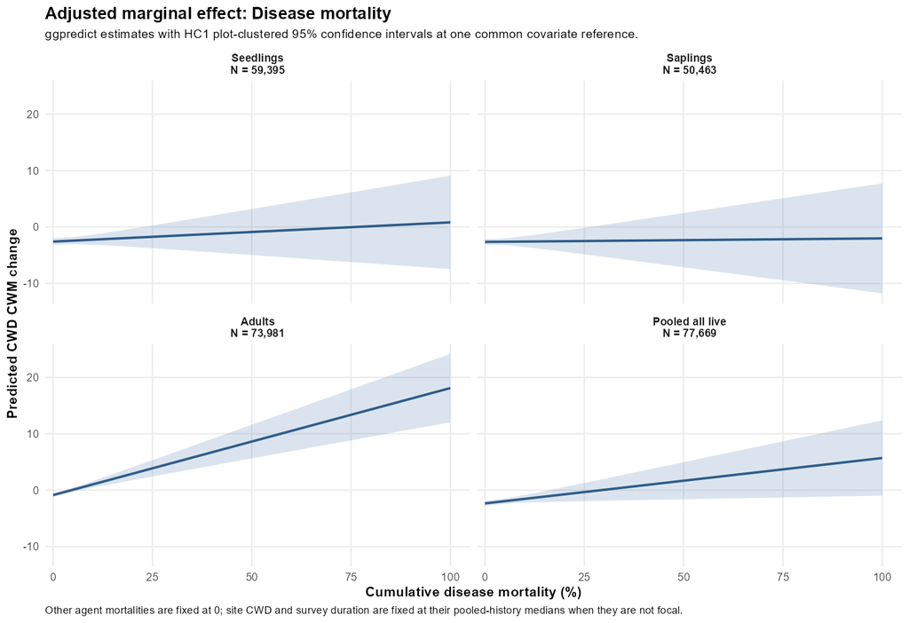

Disease mortality

HC1 plot-clustered ggpredict estimates for Seedlings, Saplings, Adults, Pooled all live

### 5.3.4 Cumulative site CWD

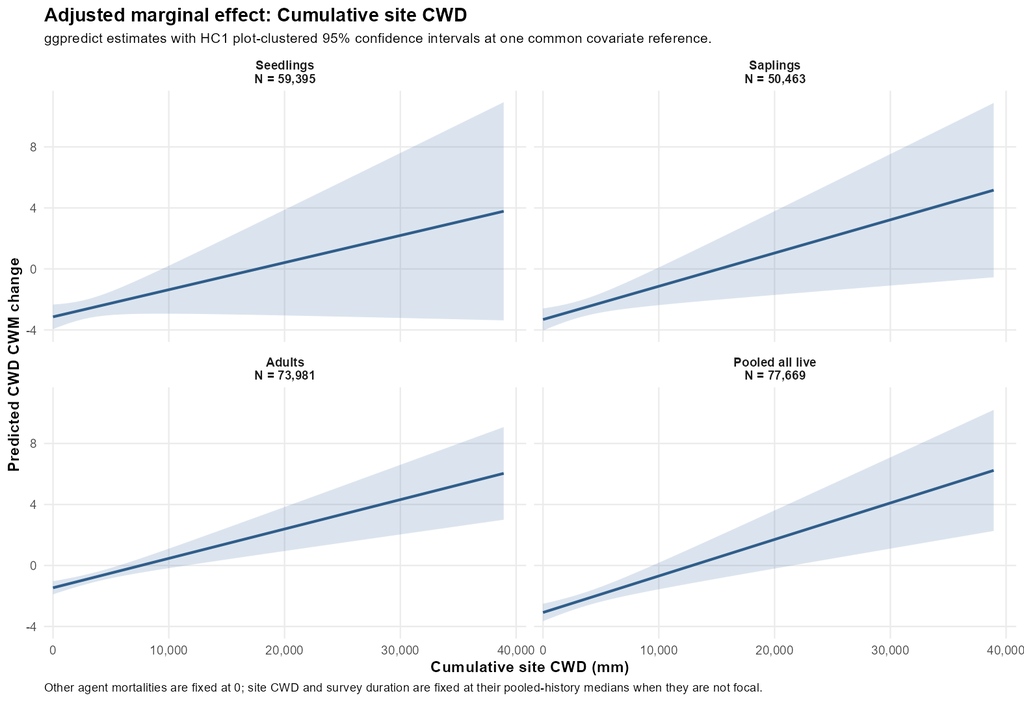

Cumulative site CWD

HC1 plot-clustered ggpredict estimates for Seedlings, Saplings, Adults, Pooled all live

# 6 Interpretation guardrails

- Mortality predictors are cumulative percentages over each complete condition history; they are not annualized rates in these preliminary models.
- Cumulative site CWD is TerraClimate `def` exposure at the FIA site, not the CWD community-niche response.
- The raw figures are descriptive. Use the model tables and marginal-effect figures when discussing covariate-adjusted model results.
- Seedlings, saplings, adults, and the exploratory pooled all-live forest are shown as four separate model columns and plot panels.